# Time Series Analysis Final Project

```r
#Load all the required packages
library(astsa)
library(xts)
```

### Data Description

#### Data Source

I have used the unemployment data set from the astsa package for this final project. Below are the details about the data set.

Data set: U.S Unemployment Origin: The data set is available in astsa package. Source not mentioned. Description: Monthly U.S Unemployment Series(1948-1978, n=372) Dataset contains unemployment count in 1000s

#### Statistical summary of the unemployment data set

Below is the statistical summary of the unemployment time series data.

Mean : **393.0424731**

Median : **366.15**

Standard deviation : **155.0507401**

Minimum value : **148**

Maximum value : **856.9**

IQR : **187.825**

#### Time series description

Time index of the first observation from unemployment data set: **1948, 1**

Time index of the last observation from unemployment data set: **1978, 12**

Frequency of the unemployment data set: **12**

Total observations in the dataset : **372**

First 10 elements of the unemployment data set: **235.1, 280.7, 264.6, 240.7, 201.4, 240.8, 241.1, 223.8, 206.1, 174.7**

### Data Exploration

The below box plot across months helps to understand the seasonal effect on the unemp data set. As we can see unemployment seems to be high in start and the mid of the year. ##### Boxplot

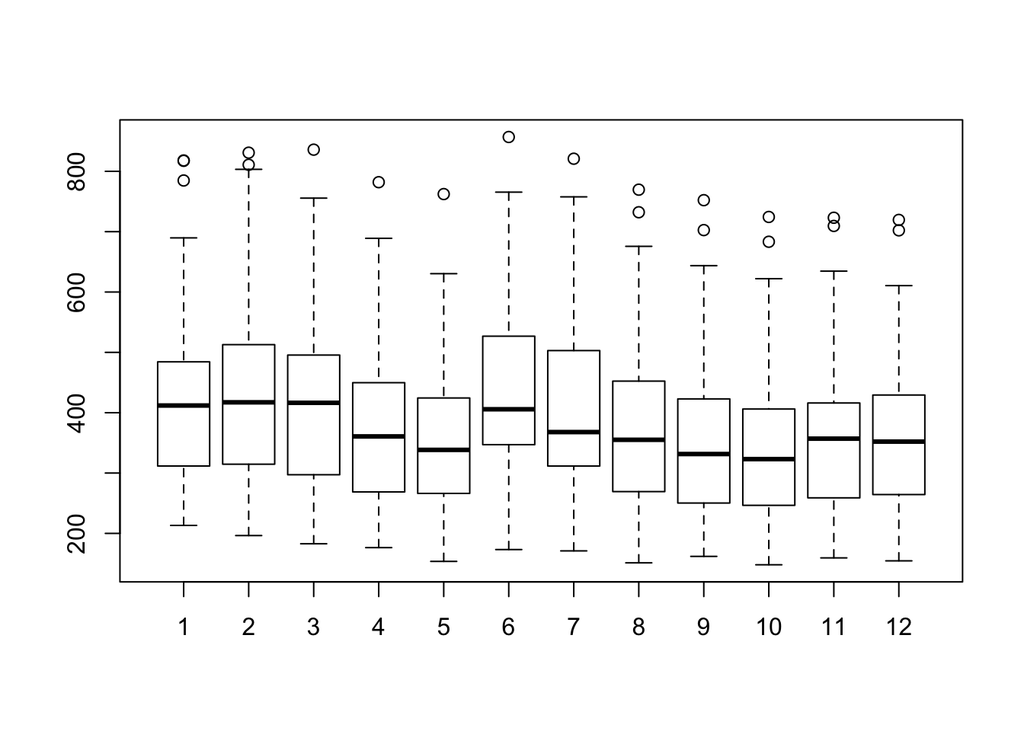

```r
boxplot(unemp~cycle(unemp))
```

Based on the below trend plot there is a Linear trend in the unemployment data set and also there is some periodic seasonality in the data set especially when we look at the data betweek 1955 and 1970.Also there is a change in mean and variance across the years in the unemployment data set.

##### Trend plot

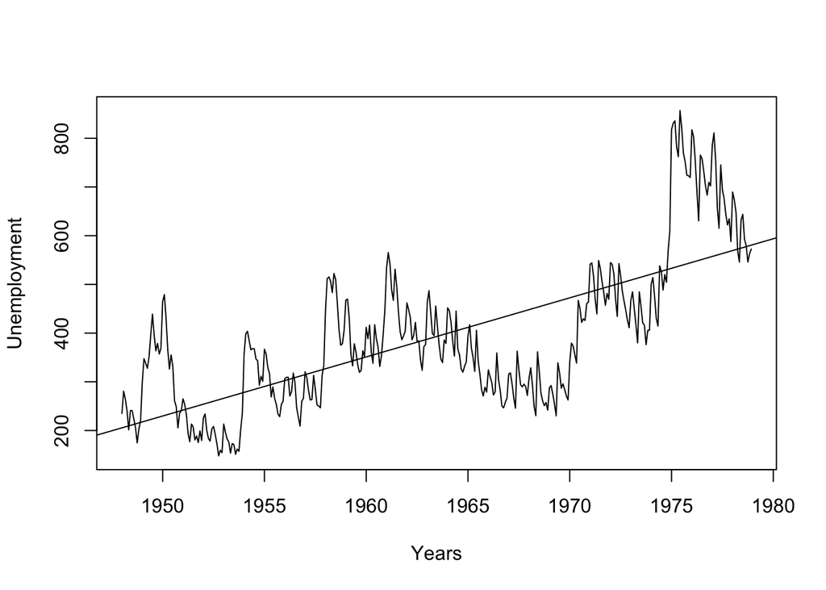

```r
plot(unemp,ylab="Unemployment",xlab="Years") # plot the raw data
abline(reg=lm(unemp~time(unemp))) # fit a trend line
```

##### Histogram

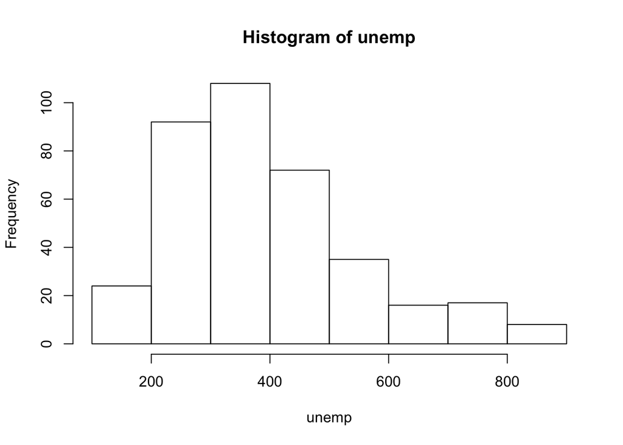

```r
hist(unemp) # plot the raw data
```

I have converted the unemp data set to xts to check the yearly mean and variance and plot them.Check the below plots to see the difference in mean and variance across the years.

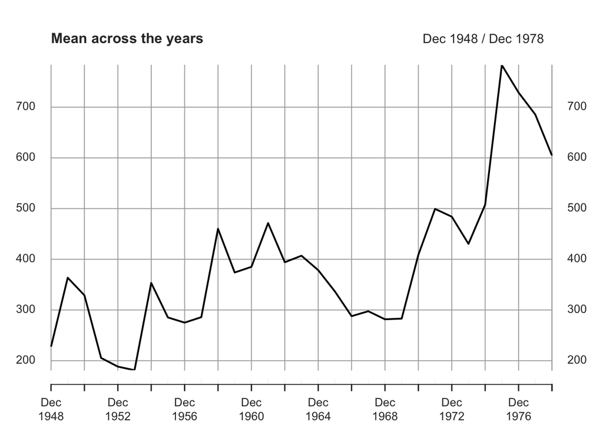

```r
unemp_xts<-as.xts(unemp) # convert the unemp ts to xts
ep<-endpoints(unemp_xts,on="years") #endpoints for each year in the dataset
plot(period.apply(unemp_xts,INDEX=ep,FUN=mean),main ="Mean across the years") # plot mean
```

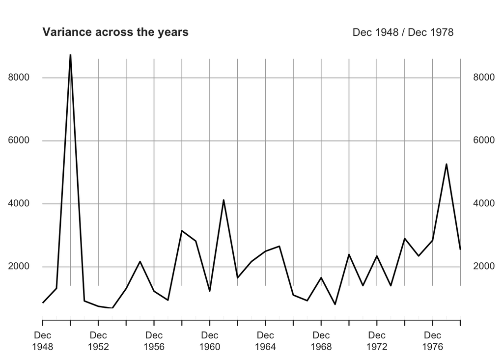

```r
plot(period.apply(unemp_xts,INDEX=ep,FUN=var),main="Variance across the years") #Plot variance
```

##### Data transformation.

As there is linear trend and seasonality in the data set I will apply the diff transformation to remove that to make the data stationary.

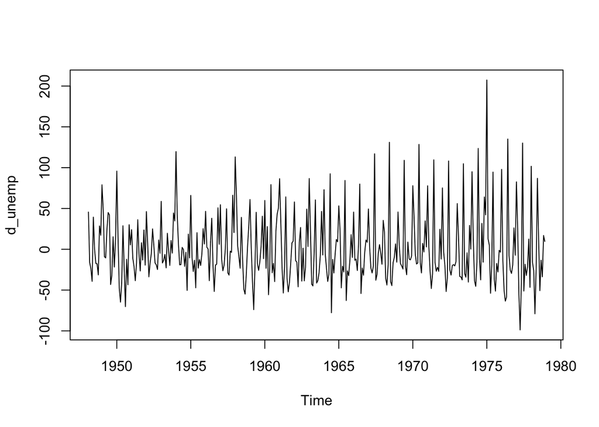

```r
d_unemp <- diff(unemp)
plot(d_unemp)
```

The above plot shows that seasonality still persistent. It can be removed by applying “Seasonal Difference Transformation”. For a periodic series the diff function in R with additional seasonal argument s can remove periodic trends.

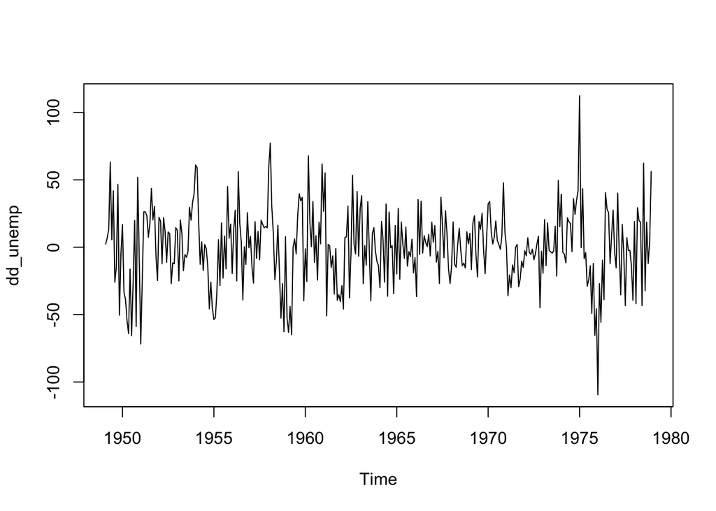

```r
dd_unemp <- diff((d_unemp), lag = 12)
plot(dd_unemp)
```

### Data Decomposition

The time series data set can be decomposed into multiple different time series. The original time series is split into 3 different components.

Seasonal: Its pattern which repeat after fixed period of time. Trend: Trend of the time series. Increasing or decreasing. Residual or Random: This is residual of the ts after the seasonal and trend components are removed

```r
unemp_de <- decompose(unemp)
sample(unemp_de$seasonal,10)
```

```
##  [1]  54.38560 -14.84593 -30.50593  54.38560 -14.84593  46.75116  30.88046
##  [8] -33.15440  54.38560  54.38560
```

```r
sample(unemp_de$trend,10)
```

```
##  [1]       NA 197.0667 400.9625 319.0125 296.7875 723.6542 274.3708
##  [8] 284.2667 410.9000 372.5625
```

```r
sample(unemp_de$random,10)
```

```
##  [1]   6.992454         NA  -6.363241 -29.921991  -3.204907 -19.385602
##  [7] -19.341435  -6.924213 -32.142963  14.136204
```

Plot trend, seasonal and residual of unemployment time series.

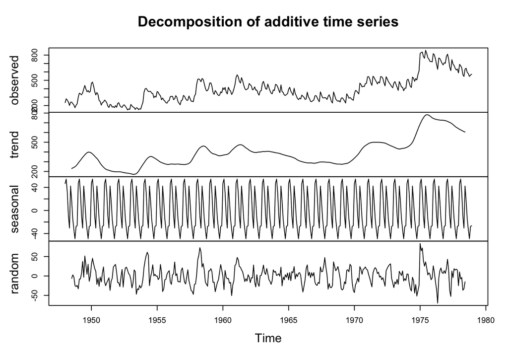

```r
plot(decompose(unemp))
```

The decomposition plot shows the observed values in unemployment time series on top and then shows the estimated trend where we can see the linear trend and then the the estimated seasonal plot shows that unemployment starts higher in Jan and goes low in April and again goes high in June and goes down at the end of the year. The random or residual shows the random component in the time series.

### Regression

```r
fit <- lm(unemp~time(unemp), na.action=NULL)
summary(fit )
```

```
##
## Call:
## lm(formula = unemp ~ time(unemp), na.action = NULL)
##
## Residuals:
##     Min      1Q  Median      3Q     Max
## -234.32  -72.71  -10.25   63.84  318.77
##
## Coefficients:
##               Estimate Std. Error t value Pr(>|t|)
## (Intercept) -2.343e+04  1.259e+03  -18.61   <2e-16 ***
## time(unemp)  1.213e+01  6.413e-01   18.92   <2e-16 ***
## ---
## Signif. codes:  0 '***' 0.001 '**' 0.01 '*' 0.05 '.' 0.1 ' ' 1
##
## Residual standard error: 110.7 on 370 degrees of freedom
## Multiple R-squared:  0.4917, Adjusted R-squared:  0.4903
## F-statistic: 357.9 on 1 and 370 DF,  p-value: < 2.2e-16
```

The residual shows the difference between the actual value and the value predicted by model. As per the result this value ranges from -234 to 318. As per the below histogram of the residulas have symmterical distribution around 0 and looks normally distributed which indicates that linear model is appropriate. The R squared or adjusted R squared value shows how close our data to the linear regression model. The value must be between 0 and 1. The closer it gets to 1 the better model fits the data. For the unemployment ts the R squared shows the value 0.49 which means the accuracy is only close to half.

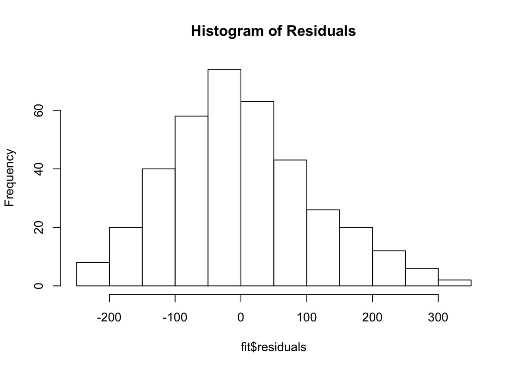

```r
hist(fit$residuals, main="Histogram of Residuals")
```

### ARMA Model

Based on the below ACF and PACF plots for the differenced unemployment data, the ACF tails off but PACF cuts off at lag2 hence we can fit AR(2) model

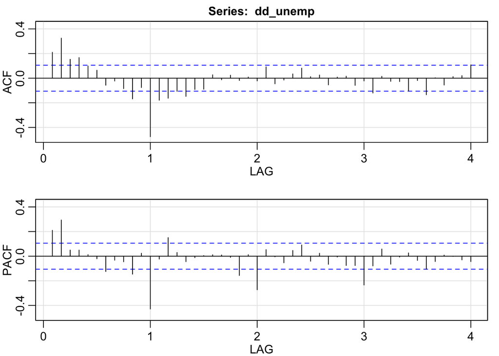

```
##         ACF  PACF
##  [1,]  0.21  0.21
##  [2,]  0.33  0.29
##  [3,]  0.15  0.05
##  [4,]  0.17  0.05
##  [5,]  0.10  0.01
##  [6,]  0.06 -0.02
##  [7,] -0.06 -0.12
##  [8,] -0.02 -0.03
##  [9,] -0.09 -0.05
## [10,] -0.17 -0.15
## [11,] -0.08  0.02
## [12,] -0.48 -0.43
## [13,] -0.18 -0.02
## [14,] -0.16  0.15
```

[output cut: 34 more lines]

```r
acf2(dd_unemp)
```

### ARIMA Model Diagnostics

#### Fit ARIMA Models with different parameters.

As we already converted the unemp time series data set to stationary above through multiple differentiation. We can use that data directly in the ARIMA model and use d =0.

##### ARIMA(1,0,0)

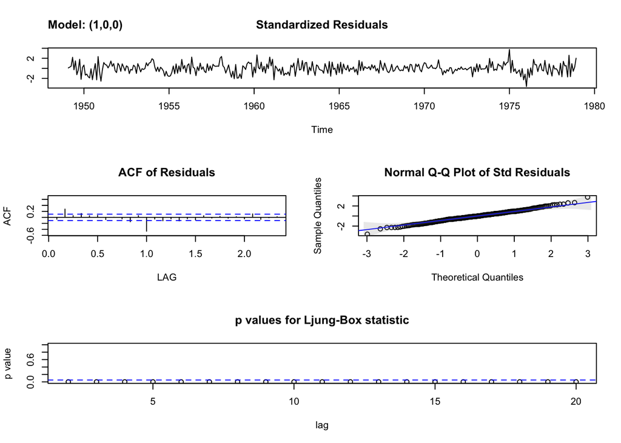

```
## $fit
##
## Call:
## stats::arima(x = xdata, order = c(p, d, q), seasonal = list(order = c(P, D,
##     Q), period = S), xreg = xmean, include.mean = FALSE, optim.control = list(trace = trc,
##     REPORT = 1, reltol = tol))
##
## Coefficients:
##          ar1    xmean
##       0.2119  -0.1837
## s.e.  0.0518   1.8422
##
## sigma^2 estimated as 757.8:  log likelihood = -1699.59,  aic = 3405.18
##
## $degrees_of_freedom
## [1] 357
##
## $ttable
##       Estimate     SE t.value p.value
## ar1     0.2119 0.0518  4.0914  0.0001
## xmean  -0.1837 1.8422 -0.0997  0.9206
##
## $AIC
## [1] 7.641613
##
## $AICc
## [1] 7.647373
##
## $BIC
## [1] 6.663248
```

```r
sarima(dd_unemp,1,0,0)
```

##### ARIMA(2,0,0)

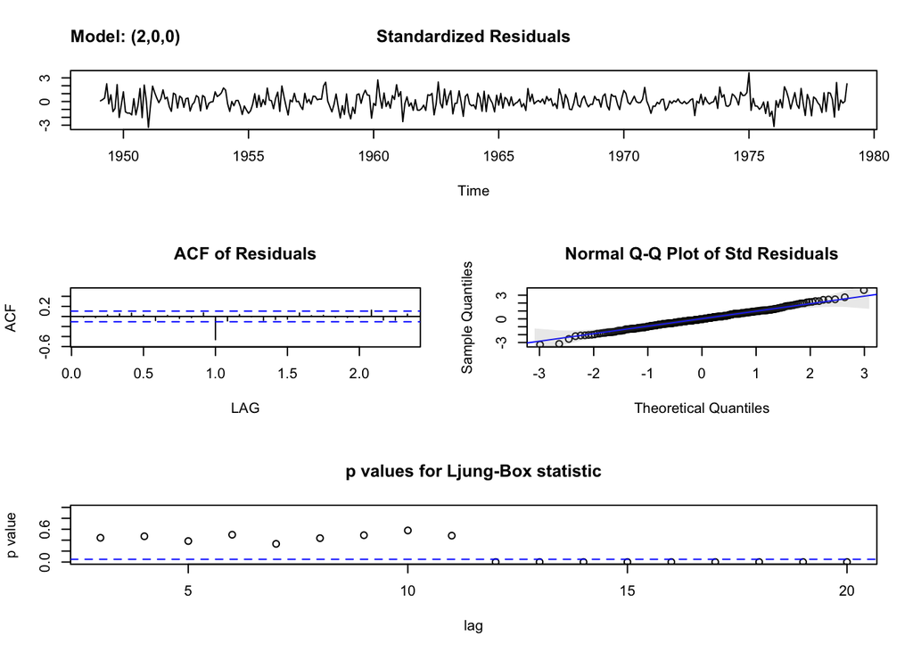

```
## $fit
##
## Call:
## stats::arima(x = xdata, order = c(p, d, q), seasonal = list(order = c(P, D,
##     Q), period = S), xreg = xmean, include.mean = FALSE, optim.control = list(trace = trc,
##     REPORT = 1, reltol = tol))
##
## Coefficients:
##          ar1     ar2    xmean
##       0.1493  0.2956  -0.0736
## s.e.  0.0506  0.0505   2.4916
##
## sigma^2 estimated as 691.7:  log likelihood = -1683.28,  aic = 3374.56
##
## $degrees_of_freedom
## [1] 356
##
## $ttable
##       Estimate     SE t.value p.value
## ar1     0.1493 0.0506  2.9520  0.0034
## ar2     0.2956 0.0505  5.8504  0.0000
## xmean  -0.0736 2.4916 -0.0295  0.9765
##
## $AIC
## [1] 7.5558
##
## $AICc
## [1] 7.561686
##
## $BIC
## [1] 6.588252
```

```r
sarima(dd_unemp,2,0,0)
```

##### ARIMA(3,0,0)

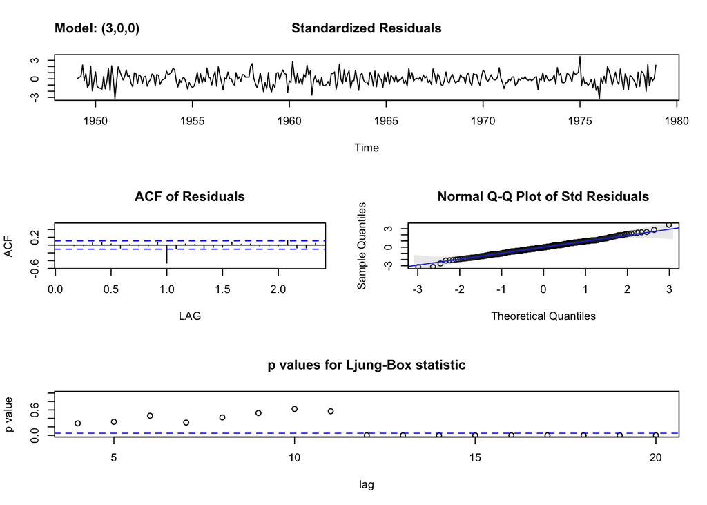

```
## $fit
##
## Call:
## stats::arima(x = xdata, order = c(p, d, q), seasonal = list(order = c(P, D,
##     Q), period = S), xreg = xmean, include.mean = FALSE, optim.control = list(trace = trc,
##     REPORT = 1, reltol = tol))
##
## Coefficients:
##          ar1     ar2     ar3    xmean
##       0.1345  0.2884  0.0487  -0.0558
## s.e.  0.0530  0.0511  0.0529   2.6126
##
## sigma^2 estimated as 690:  log likelihood = -1682.86,  aic = 3375.71
##
## $degrees_of_freedom
## [1] 355
##
## $ttable
##       Estimate     SE t.value p.value
## ar1     0.1345 0.0530  2.5405  0.0115
## ar2     0.2884 0.0511  5.6455  0.0000
## ar3     0.0487 0.0529  0.9210  0.3577
## xmean  -0.0558 2.6126 -0.0214  0.9830
##
## $AIC
## [1] 7.558993
##
## $AICc
## [1] 7.565037
##
## $BIC
## [1] 6.602261
```

```r
sarima(dd_unemp,3,0,0)
```

##### ARIMA(0,0,1)

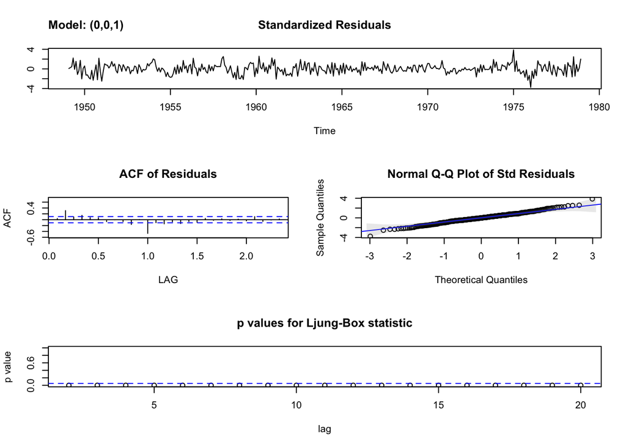

```
## $fit
##
## Call:
## stats::arima(x = xdata, order = c(p, d, q), seasonal = list(order = c(P, D,
##     Q), period = S), xreg = xmean, include.mean = FALSE, optim.control = list(trace = trc,
##     REPORT = 1, reltol = tol))
##
## Coefficients:
##          ma1    xmean
##       0.1344  -0.2059
## s.e.  0.0418   1.6619
##
## sigma^2 estimated as 771:  log likelihood = -1702.68,  aic = 3411.35
##
## $degrees_of_freedom
## [1] 357
##
## $ttable
##       Estimate     SE t.value p.value
## ma1     0.1344 0.0418  3.2177  0.0014
## xmean  -0.2059 1.6619 -0.1239  0.9015
##
## $AIC
## [1] 7.65888
##
## $AICc
## [1] 7.664639
##
## $BIC
## [1] 6.680514
```

```r
sarima(dd_unemp,0,0,1)
```

##### ARIMA(1,0,1)

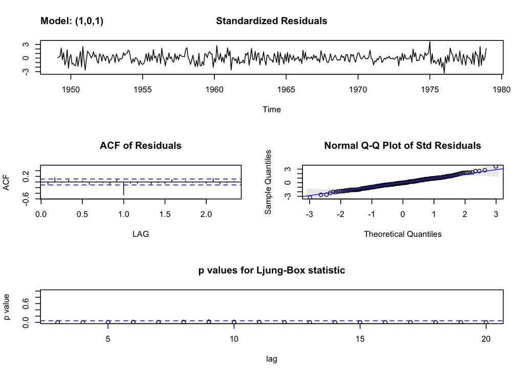

```
## $fit
##
## Call:
## stats::arima(x = xdata, order = c(p, d, q), seasonal = list(order = c(P, D,
##     Q), period = S), xreg = xmean, include.mean = FALSE, optim.control = list(trace = trc,
##     REPORT = 1, reltol = tol))
##
## Coefficients:
##          ar1      ma1    xmean
##       0.7811  -0.5694  -0.0060
## s.e.  0.0605   0.0724   2.7533
##
## sigma^2 estimated as 711.5:  log likelihood = -1688.33,  aic = 3384.66
##
## $degrees_of_freedom
## [1] 356
##
## $ttable
##       Estimate     SE t.value p.value
## ar1     0.7811 0.0605 12.9060  0.0000
## ma1    -0.5694 0.0724 -7.8629  0.0000
## xmean  -0.0060 2.7533 -0.0022  0.9983
##
## $AIC
## [1] 7.584141
##
## $AICc
## [1] 7.590027
##
## $BIC
## [1] 6.616592
```

```r
sarima(dd_unemp,1,0,1)
```

#### Best model

Below are the AIC and BIC values of different models captured from the above results. Based on this table the AIC and BIC values are low for the model ARIMA(2,0,0) and then ARIMA(3,0,0) and it increases when the parameter is added. As we can see from the t-table for (3,0,0) the third AR parameter is not significantly different from 0 and the first 2 AR parameters are approximately same hence **ARIMA(2,0,0)** model is the best fit for this data.

| ARIMA Model | AIC | BIC |
| --- | --- | --- |
| (1,0,0) | 7.6416 | 6.6632 |
| (2,0,0) | 7.5558 | 6.5883 |
| (3,0,0) | 7.5590 | 6.6022 |
| (0,0,1) | 7.6589 | 6.6805 |
| (1,0,1) | 7.5841 | 6.6166 |

#### Resdiual Diagnostics

**Standardized Residuals:** As we can see in the Standardized Residual plot below there are no patterns and it looks like white noise. Also as per this plot the mean looks to be close to 0 and there is not much change in the variance acorss the years.(except for few years like 1975)

**Normal QQ Plot:** The residuals are normal distribution as the points are falling on the line in QQ plot

##### ARIMA(2,0,0)

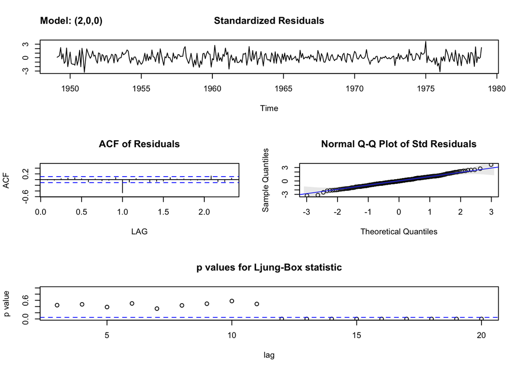

```
## $fit
##
## Call:
## stats::arima(x = xdata, order = c(p, d, q), seasonal = list(order = c(P, D,
##     Q), period = S), xreg = xmean, include.mean = FALSE, optim.control = list(trace = trc,
##     REPORT = 1, reltol = tol))
##
## Coefficients:
##          ar1     ar2    xmean
##       0.1493  0.2956  -0.0736
## s.e.  0.0506  0.0505   2.4916
##
## sigma^2 estimated as 691.7:  log likelihood = -1683.28,  aic = 3374.56
##
## $degrees_of_freedom
## [1] 356
##
## $ttable
##       Estimate     SE t.value p.value
## ar1     0.1493 0.0506  2.9520  0.0034
## ar2     0.2956 0.0505  5.8504  0.0000
## xmean  -0.0736 2.4916 -0.0295  0.9765
##
## $AIC
## [1] 7.5558
##
## $AICc
## [1] 7.561686
##
## $BIC
## [1] 6.588252
```

```r
sarima(dd_unemp,2,0,0)
```